# Sugarcane Decomposition

Jessica Mulcrone

2023-09-04

## Task:

To determine if elevated-lipid sugarcane lines decompose differently than wild type sugarcane. Results will provide insight into sugarcane lipid decomposition and determine possible ecological and environmental impacts of growing elevated-lipid sugarcane crops.

## Overview:

Energy crops such as sugarcane are engineered to contain higher lipid contents (up to 3% lipid as opposed to .25%) in order to provide more oil per plant. Plants with elevated lipid content may affect soil organic matter (SOM) through a variety of mechanisms including decomposition rate. It is possible that high-lipid sugarcane material would decompose more slowly than wild-type due to the lower quality lipid substrates.

Leaf and root litter bags from three sugarcane lines (one wild type [WT], two elevated-lipid [17T and 1566]) were deployed at the University of Illinois Energy Farm in Urbana, IL, USA and collected in subsets at several intervals throughout the year. Mass lost from these bags was measured, corrected for soil contamination, and combined with carbon and nitrogen data from an elemental analyzer to determine differences in mass lost and percent decomposition of nutrients across lines.

## Data Sources:

Mock data that was used to check the R script is used in this analysis for confidentiality reasons. A link to the paper with the real-world data will be updated when forthcoming and published.

## Data Cleaning and Manipulation:

Libraries were imported and working directory was set.

```r
library(dplyr)
library(ggplot2)
library(readxl)
library(ggpubr)
library(rstatix)
library(tidyverse)
library(knitr)

rm (list = ls())

setwd ("/Users/mulcron3/Desktop/sugarcane_data_8_25")
```

Data files were imported.

```r
data.percentashsoil <- read_excel("sugarcane_ash_mock.xlsx", sheet="soil_final")
data.percentashleaf <- read_excel("sugarcane_ash_mock.xlsx", sheet="leaf_final")
data.percentashroot <- read_excel("sugarcane_ash_mock.xlsx", sheet="root_final")
data.leafweight <- read_excel("sugarcane_litterbag_weights_mock.xlsx", sheet="leaf_dry_weights")
data.rootweight <- read_excel("sugarcane_litterbag_weights_mock.xlsx", sheet="root_dry_weights")
data.leafcandn_2 <- read_excel("sugarcane_C_N_mock.xlsx", sheet="cn_leaves")
data.rootcandn_2 <- read_excel("sugarcane_C_N_mock.xlsx", sheet="cn_roots")
data.soil <- read_excel("sugarcane_C_N_mock.xlsx", sheet="cn_soil")
```

Soil ashing data reps were averaged and split into root soil and leaf soil. Unnecessary columns were deleted.

```r
mean.soilash <- summarize(group_by(data.percentashsoil, Obs,
                                   litter_source, block, Sample_ID),
                          mean_soilash = mean (ash_mass_pct))

mean.soilashleaves <-filter(mean.soilash, grepl("leaf", Sample_ID))

mean.soilashroots <- filter(mean.soilash, grepl("root", Sample_ID))
```

Leaf and root ashing data reps were averaged and split between samples and stock. Unnecessary columns were deleted and the stock mean column was renamed to differentiate it from sample mean columns.

```r
mean.leafashraw <- summarise(group_by(data.percentashleaf, Obs, litter_source,
                                      litter_line, litter_date, block, litterbag_number),
                             mean_leafash = mean (ash_mass_pct),
                             n_leafash=n())

mean.stockleafashraw <- filter(mean.leafashraw, Obs == "Stock")

mean.stockleafash <- summarise (group_by(mean.stockleafashraw,
                                         litter_source, litter_line,
                                         mean_leafash))

names(mean.stockleafash)[names(mean.stockleafash)
                         == 'mean_leafash'] <- 'mean_stockleafash'

mean.leafash <- filter (mean.leafashraw, Obs != "Stock")

mean.rootashraw <- summarise (group_by(data.percentashroot, Obs, litter_source,
                                       litter_line, litter_date, block,litterbag_number),
                              mean_rootash = mean (ash_mass_pct),
                              n_leafash=n())

mean.stockrootashraw <- filter (mean.rootashraw, Obs == "Stock")

mean.stockrootash <- summarise (group_by(mean.stockrootashraw,
                                         litter_source, litter_line,
                                         mean_rootash))

names(mean.stockrootash)[names(mean.stockrootash)
                         == 'mean_rootash'] <- 'mean_stockrootash'

mean.rootash <- filter (mean.rootashraw, Obs != "Stock")
```

Columns for percent ash of samples’ corresponding soil and percent ash of the litter sample were added.

```r
litterleaf.correspondingsoilash <- merge(mean.leafash, mean.soilashleaves,
                                         by = c('litter_source', 'block'))

litterleaf.compiled <- merge(litterleaf.correspondingsoilash,
                             mean.stockleafash,
                             by = c('litter_source', 'litter_line'))

litterroot.correspondingsoilash <- merge(mean.rootash, mean.soilashroots,
                                         by = c('litter_source', 'block'))

litterroot.compiled <- merge(litterroot.correspondingsoilash,
                             mean.stockrootash,
                             by = c('litter_source', 'litter_line'))
```

Percent C and N for soils, roots, and leaves were calculated.

```r
leaf_c_and_n_means <- summarize(group_by(data.leafcandn_2, Obs,litterbag_number,
                                         litter_source, block),
                                mean_c = mean (C),
                                mean_n = mean (N))

root_c_and_n_means <- summarize(group_by(data.rootcandn_2, Obs, litterbag_number,
                                         litter_source, block),
                                mean_c = mean (C),
                                mean_n = mean (N))

soil_c_and_n_means <- summarize(group_by(data.soil,
                                         litter_source, block, Sample_ID),
                                mean_c = mean (C),
                                mean_n = mean (N))
```

Leaf C and N data was split by chamber and field.

```r
c_and_n_means_chamber01 <- filter (leaf_c_and_n_means,
                                   litter_source == "cham_01")

c_and_n_means_field01 <- filter (leaf_c_and_n_means,
                                 litter_source == "field_01")

soil_c_and_n_means_field01 <- filter (soil_c_and_n_means,
                                      litter_source == "field_01")


soil_c_and_n_means_chamber01 <- filter (soil_c_and_n_means,
                                        litter_source == "cham_01")
```

Soil C and N data was split by leaves and roots.

```r
soil_c_and_n_chamber01_leaves <- filter (soil_c_and_n_means_chamber01,
                                         Sample_ID < 11)


soil_c_and_n_chamber01_roots <- filter (soil_c_and_n_means_chamber01,
                                        Sample_ID > 10)
```

C and N soil data was merged with the C and N litter data, and columns were renamed to be unique for combination with litter data.

```r
chamber01_c_and_n_leaf_compiled <- merge (c_and_n_means_chamber01,
                                          soil_c_and_n_chamber01_leaves,
                                          by = c('block', 'litter_source'))

field01_c_and_n_leaf_compiled <- merge (c_and_n_means_field01,
                                        soil_c_and_n_means_field01,
                                        by = c('block', 'litter_source'))

root_c_and_n_compiled <- merge (root_c_and_n_means, soil_c_and_n_chamber01_roots,
                                by = c('block', 'litter_source'))


colnames(chamber01_c_and_n_leaf_compiled)[4]  <- "litterbag_number"
colnames(chamber01_c_and_n_leaf_compiled)[5]  <- "mean_c_leaf"
colnames(chamber01_c_and_n_leaf_compiled)[6]  <- "mean_n_leaf"
colnames(chamber01_c_and_n_leaf_compiled)[7]  <- "soil_ID"
colnames(chamber01_c_and_n_leaf_compiled)[8]  <- "mean_c_soil"
colnames(chamber01_c_and_n_leaf_compiled)[9]  <- "mean_n_soil"

colnames(field01_c_and_n_leaf_compiled)[4]  <- "litterbag_number"
colnames(field01_c_and_n_leaf_compiled)[5]  <- "mean_c_leaf"
colnames(field01_c_and_n_leaf_compiled)[6]  <- "mean_n_leaf"
colnames(field01_c_and_n_leaf_compiled)[7]  <- "soil_ID"
colnames(field01_c_and_n_leaf_compiled)[8]  <- "mean_c_soil"
colnames(field01_c_and_n_leaf_compiled)[9]  <- "mean_n_soil"

colnames(root_c_and_n_compiled)[4]  <- "litterbag_number"
colnames(root_c_and_n_compiled)[5]  <- "mean_c_root"
colnames(root_c_and_n_compiled)[6]  <- "mean_n_root"
colnames(root_c_and_n_compiled)[7]  <- "soil_ID"
colnames(root_c_and_n_compiled)[8]  <- "mean_c_soil"
colnames(root_c_and_n_compiled)[9]  <- "mean_n_soil"
```

## Key Questions:

1. Do elevated-lipid sugarcane leaf samples decompose more slowly than wild type?
2. Do elevated-lipid sugarcane root samples decompose more slowly than wild type?
3. Does the carbon in elevated-lipid sugarcane leaf or root samples decompose differently than wild type?
4. Does the nitrogen in elevated-lipid sugarcane leaf samples decompose differently than wild type?
5. Are there concerning outliers in the data?

## Analysis, Key Results, and Visualizations:

Percent actually litter (as opposed to soil) was calculated using Equation from literatur for leaves and roots (Blair et al. 1988 sBB, DOI:10.1016/0038-0717(88)90154-X).

```r
litterleaf.compiled <- litterleaf.compiled %>%
  mutate(percent_actually_litterleaf
         =(((100-mean_leafash) - (100-mean_soilash))
           / ((100-mean_stockleafash) - (100-mean_soilash))
           *100))

litterroot.compiled<- litterroot.compiled %>%
  mutate(percent_actually_litterroot
         =(((100-mean_rootash) - (100-mean_soilash))
           / ((100-mean_stockrootash) - (100-mean_soilash))
           *100))
```

Percent of sample decomposed was calculated for leaves and roots.

```r
# merge weight data from retrieved sample bags with the percent actually litter data

litterleaf.compiled <-merge(data.leafweight, select(litterleaf.compiled, -c(Obs.x, Obs.y, litter_date)),
                            by = c("litterbag_number", "litter_source",
                                   "litter_line", "block"))

litterroot.compiled <-merge(data.rootweight, select(litterroot.compiled, -c(Obs.x, Obs.y, litter_date)),
                            by = c("litterbag_number", "litter_source",
                                   "litter_line", "block"))

# multiply percent actually litter by weights of retrieved sample bags and subtract results from initial weight

litterleaf.compiled <- litterleaf.compiled %>%
  mutate(post_weight_thats_actually_litter
         = (post_litter_wt_g * percent_actually_litterleaf/100))

litterleaf.compiled <- litterleaf.compiled %>%
  mutate(pre_minus_adj_post
         = (pre_litter_wt_g - post_weight_thats_actually_litter))

litterroot.compiled <- litterroot.compiled %>%
  mutate(post_weight_thats_actually_litter
         = (post_litterbag_wt_g * percent_actually_litterroot/100))

litterroot.compiled <- litterroot.compiled %>%
  mutate(pre_minus_adj_post
         = (pre_litter_wt_g - post_weight_thats_actually_litter))

# divide adjusted post weight by initial weight

litterleaf.compiled <- litterleaf.compiled %>%
  mutate(pct_mass_lost_leaf
         = (pre_minus_adj_post / pre_litter_wt_g))

litterroot.compiled <- litterroot.compiled %>%
  mutate(pct_mass_lost_root
         = (pre_minus_adj_post / pre_litter_wt_g))
```

Leaf data was split between chamber grown and field grown.

```r
litterleafcham01.compiled <- filter (litterleaf.compiled,
                                     litter_source == "cham_01")

litterleaffield01.compiled <- filter (litterleaf.compiled,
                                      litter_source == "field_01")
```

## Figure 1. Percent Mass Lost Over Time

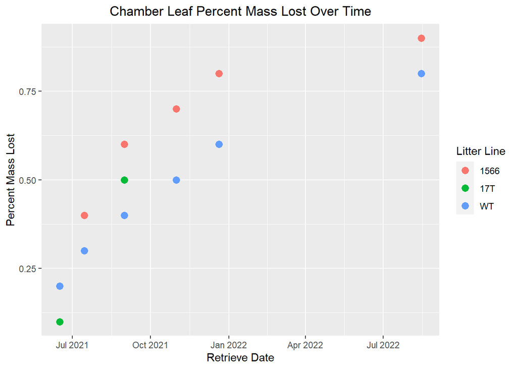

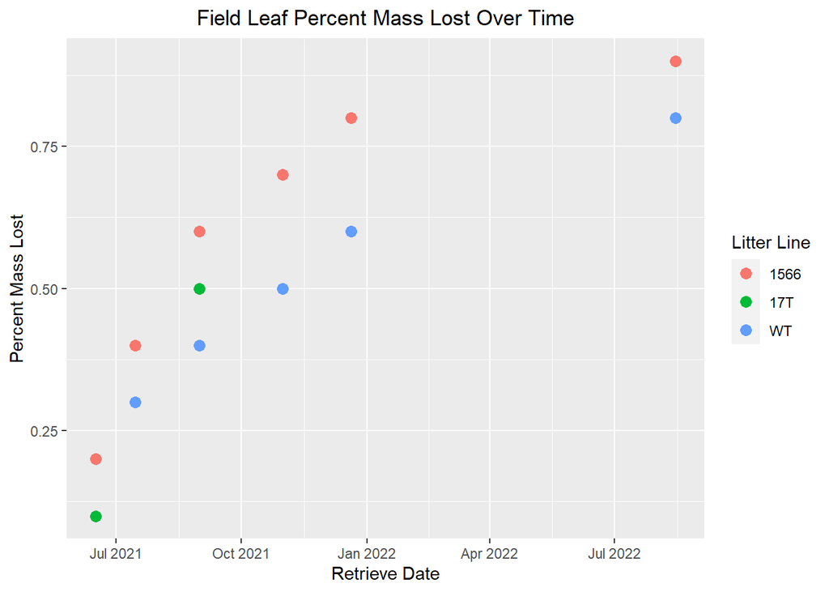

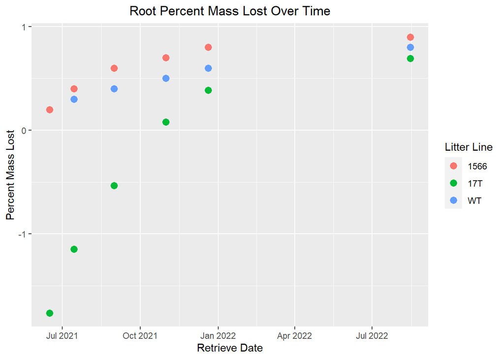

Data for percent actually litter was combined with the C and N data

```r
#trim down the percentage actual leaf data in prep to combine with C N data

litterleafcham01.compiled_2 <- litterleafcham01.compiled %>% select(-c(litter_source, Obs,
                                                                       litter_date, zip_color, block,
                                                                       retrieve_date, rand_num, Jack_post_litter_rewt_g,
                                                                       note, Sample_ID))


litterleaffield01.compiled_2 <- litterleaffield01.compiled %>% select(-c(litter_source, Obs,
                                                                         litter_date, zip_color, block,
                                                                         retrieve_date, rand_num, Jack_post_litter_rewt_g,
                                                                         note, Sample_ID))

litterroot.compiled_2 <- litterroot.compiled %>% select(-c(litter_source, Obs,
                                                           litter_date, zip_color, block,
                                                           retrieve_date, rand_num,
                                                           note, Sample_ID))

#combine the trimmed percent actual leaf data and C N data

chamber01_c_and_n_leaf_compiled_2 <- merge (chamber01_c_and_n_leaf_compiled,
                                            litterleafcham01.compiled_2,
                                            by = c('litterbag_number'))

field01_c_and_n_leaf_compiled_2 <- merge (field01_c_and_n_leaf_compiled,
                                          litterleaffield01.compiled_2,
                                          by = c('litterbag_number'))

root_c_and_n_compiled_2 <- merge (root_c_and_n_compiled,
                                  litterroot.compiled_2,
                                  by = c('litterbag_number'))
```

Percent C and N left in each retrieved litter bag was calculated.

```r
chamber01_c_and_n_leaf_compiled_3 <- chamber01_c_and_n_leaf_compiled_2 %>%
  mutate(percent_c_leaf = (((mean_c_leaf/100) -
                              ((1 - (percent_actually_litterleaf/100)) * (mean_c_soil/100)))
                           / (percent_actually_litterleaf/100)))

field01_c_and_n_leaf_compiled_3 <- field01_c_and_n_leaf_compiled_2 %>%
  mutate(percent_c_leaf = (((mean_c_leaf/100) -
                              ((1 - (percent_actually_litterleaf/100)) * (mean_c_soil/100)))
                           / (percent_actually_litterleaf/100)))

root_c_and_n_compiled_3 <- root_c_and_n_compiled_2 %>%
  mutate(percent_c_root = (((mean_c_root/100) -
                              ((1 - (percent_actually_litterroot/100)) * (mean_c_soil/100)))
                           / (percent_actually_litterroot/100)))

chamber01_c_and_n_leaf_compiled_4 <- chamber01_c_and_n_leaf_compiled_3 %>%
  mutate(percent_n_leaf = (((mean_n_leaf/100) -
                              ((1 - (percent_actually_litterleaf/100)) * (mean_n_soil/100)))
                           / (percent_actually_litterleaf/100)))


field01_c_and_n_leaf_compiled_4 <- field01_c_and_n_leaf_compiled_3 %>%
  mutate(percent_n_leaf = (((mean_n_leaf/100) -
                              ((1 - (percent_actually_litterleaf/100)) * (mean_n_soil/100)))
                           / (percent_actually_litterleaf/100)))


root_c_and_n_compiled_4 <- root_c_and_n_compiled_3 %>%
  mutate(percent_n_root = (((mean_n_root/100) -
                              ((1 - (percent_actually_litterroot/100)) * (mean_n_soil/100)))
                           / (percent_actually_litterroot/100)))
```

Mass of C and N in each retrieved litter bag was calculated.

```r
chamber01_c_and_n_leaf_compiled_5 <- chamber01_c_and_n_leaf_compiled_4 %>%
  mutate(mass_c_leaf= (percent_c_leaf * (percent_actually_litterleaf/100)
                       * post_litter_wt_g ))

field01_c_and_n_leaf_compiled_5 <- field01_c_and_n_leaf_compiled_4 %>%
  mutate(mass_c_leaf= (percent_c_leaf * (percent_actually_litterleaf/100)
                       * post_litter_wt_g ))

root_c_and_n_compiled_5 <- root_c_and_n_compiled_4 %>%
  mutate(mass_c_root= (percent_c_root * (percent_actually_litterroot/100)
                       * post_litterbag_wt_g ))

chamber01_c_and_n_leaf_compiled_6 <- chamber01_c_and_n_leaf_compiled_5 %>%
  mutate(mass_n_leaf= (percent_n_leaf * (percent_actually_litterleaf/100)
                       * post_litter_wt_g ))

field01_c_and_n_leaf_compiled_6 <- field01_c_and_n_leaf_compiled_5 %>%
  mutate(mass_n_leaf= (percent_n_leaf * (percent_actually_litterleaf/100)
                       * post_litter_wt_g ))

root_c_and_n_compiled_6 <- root_c_and_n_compiled_5 %>%
  mutate(mass_n_root= (percent_n_root * (percent_actually_litterroot/100)
                       * post_litterbag_wt_g ))
```

C and N data was filtered for time point zero, labeled as such, and merged back with corresponding retrieved litterbags.

```r
#--Filter C and N percent for time zero

leaf_cham01_initial_c_and_n <- filter (chamber01_c_and_n_leaf_compiled_6,
                                       retrieve_time == 0)

#--Trim data for retrieve time 0

leaf_cham01_initial_c_and_n_2 <- leaf_cham01_initial_c_and_n %>%
  select(litter_line, block, percent_c_leaf,
         percent_n_leaf, mass_c_leaf, mass_n_leaf)

#--Rename coloumns for retrieve time 0 to prepare to merge

colnames(leaf_cham01_initial_c_and_n_2)[3]  <- "per_c_initial"
colnames(leaf_cham01_initial_c_and_n_2)[4]  <- "per_n_initial"
colnames(leaf_cham01_initial_c_and_n_2)[5]  <- "mass_c_int"
colnames(leaf_cham01_initial_c_and_n_2)[6]  <- "mass_n_int"

#--Filter C and N data for all other time points

leaf_cham01_c_and_n <- filter (chamber01_c_and_n_leaf_compiled_6,
                               retrieve_time != 0)

#--Merge renamed time 0 and all other time points

leaf_cham01_c_and_n_2 <- merge (leaf_cham01_c_and_n,leaf_cham01_initial_c_and_n_2,
                                by = c('litter_line', 'block'))

leaf_field01_initial_c_and_n <- filter (field01_c_and_n_leaf_compiled_6,
                                        retrieve_time == 0)

leaf_field01_initial_c_and_n_2 <- leaf_field01_initial_c_and_n %>%
  select(litter_line, block, percent_c_leaf,
         percent_n_leaf, mass_c_leaf, mass_n_leaf)

colnames(leaf_field01_initial_c_and_n_2)[3]  <- "per_c_initial"
colnames(leaf_field01_initial_c_and_n_2)[4]  <- "per_n_initial"
colnames(leaf_field01_initial_c_and_n_2)[5]  <- "mass_c_int"
colnames(leaf_field01_initial_c_and_n_2)[6]  <- "mass_n_int"


leaf_field01_c_and_n <- filter (field01_c_and_n_leaf_compiled_6,
                                retrieve_time != 0)

leaf_field01_c_and_n_2 <- merge (leaf_field01_c_and_n,leaf_field01_initial_c_and_n_2,
                                 by = c('litter_line', 'block'))

root_initial_c_and_n <- filter (root_c_and_n_compiled_6,
                                retrieve_time == 0)

root_initial_c_and_n_2 <- root_initial_c_and_n %>%
  select(litter_line, block, percent_c_root,
         percent_n_root, mass_c_root, mass_n_root )

colnames(root_initial_c_and_n_2)[3]  <- "per_c_initial"
colnames(root_initial_c_and_n_2)[4]  <- "per_n_initial"
colnames(root_initial_c_and_n_2)[5]  <- "mass_c_int"
colnames(root_initial_c_and_n_2)[6]  <- "mass_n_int"


root_c_and_n <- filter (root_c_and_n_compiled_6,
                        retrieve_time != 0)

root_c_and_n_2 <- merge (root_c_and_n,root_initial_c_and_n_2,
                         by = c('litter_line', 'block'))
```

Relative percent was calculated.

```r
leaf_cham01_c_and_n_3 <- leaf_cham01_c_and_n_2 %>%
  mutate (per_c_rel = (mass_c_leaf / mass_c_int))

leaf_cham01_c_and_n_4 <- leaf_cham01_c_and_n_3 %>%
  mutate (per_n_rel = (mass_n_leaf / mass_n_int))

leaf_field01_c_and_n_3 <- leaf_field01_c_and_n_2 %>%
  mutate (per_c_rel = (mass_c_leaf / mass_c_int))

leaf_field01_c_and_n_4 <- leaf_field01_c_and_n_3 %>%
  mutate (per_n_rel = (mass_n_leaf / mass_n_int))

root_c_and_n_3 <- root_c_and_n_2 %>%
  mutate (per_c_rel = (mass_c_root / mass_c_int))

root_c_and_n_4 <- root_c_and_n_3 %>%
  mutate (per_n_rel = (mass_n_root / mass_n_int))
```

## Figure 2. Relative Percent Carbon and Nitrogen Remaining

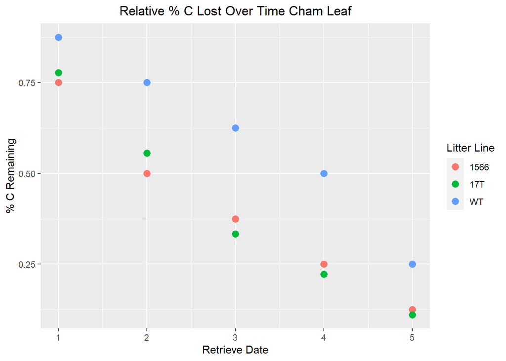

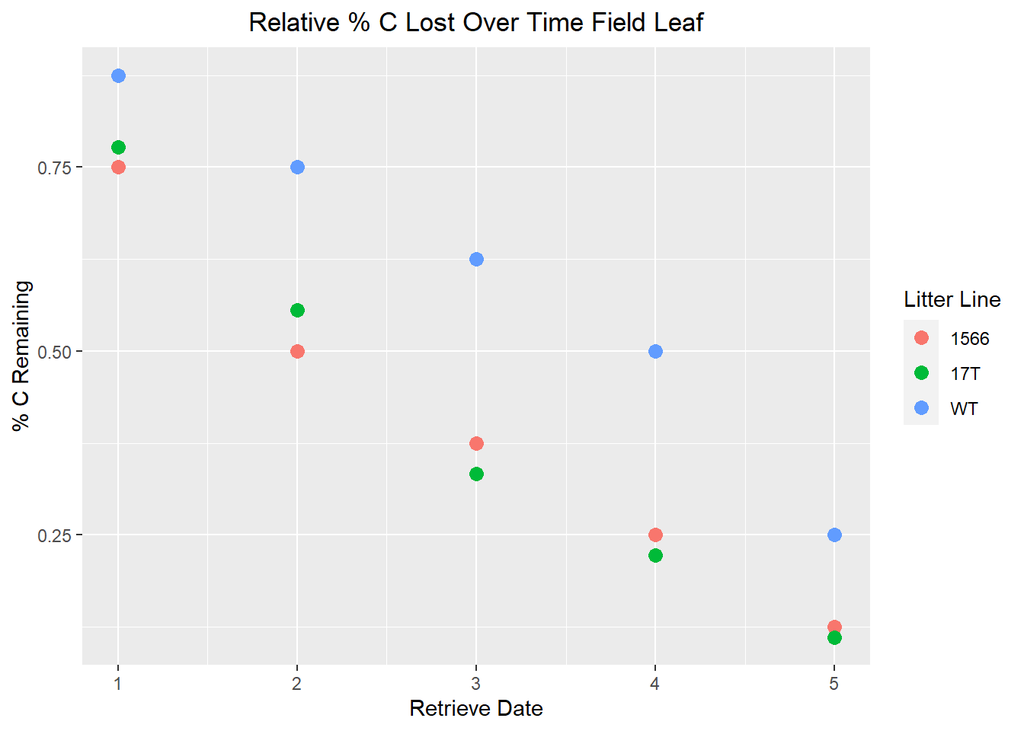

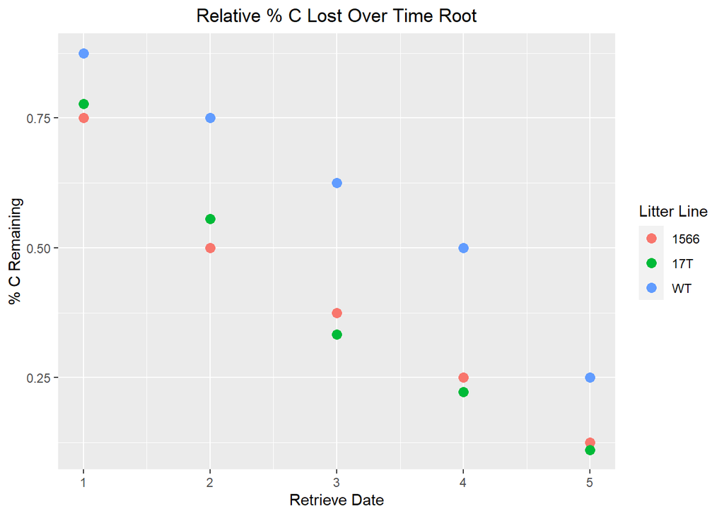

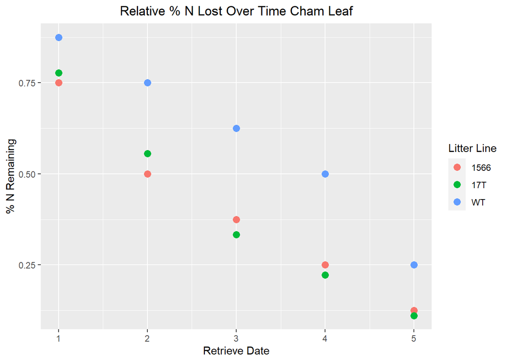

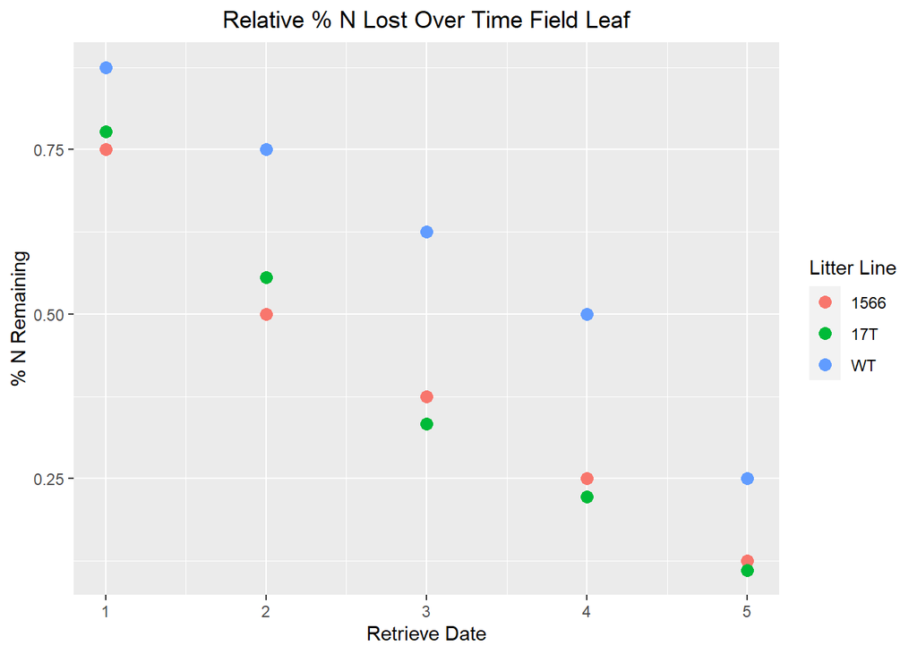

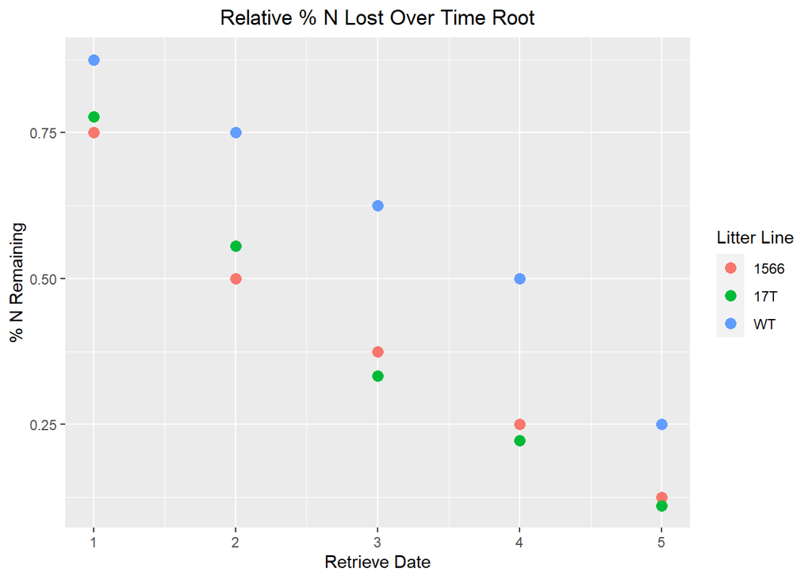

*Does the carbon in elevated-lipid sugarcane leaf or root samples decompose differently than wild type? Does the nitrogen in elevated-lipid sugarcane leaf samples decompose differently than wild type?*

**The carbon and nitrogen in elevated-lipid sugarcane leaf and root samples decompose more quickly than the carbon and nitrogen in wild type litter.** Patterns for graphs are identical because of the simplicity of mock data set to confirm different elements of the script.

## Figure 3. Relative Percent Carbon and Nitrogen Remaining

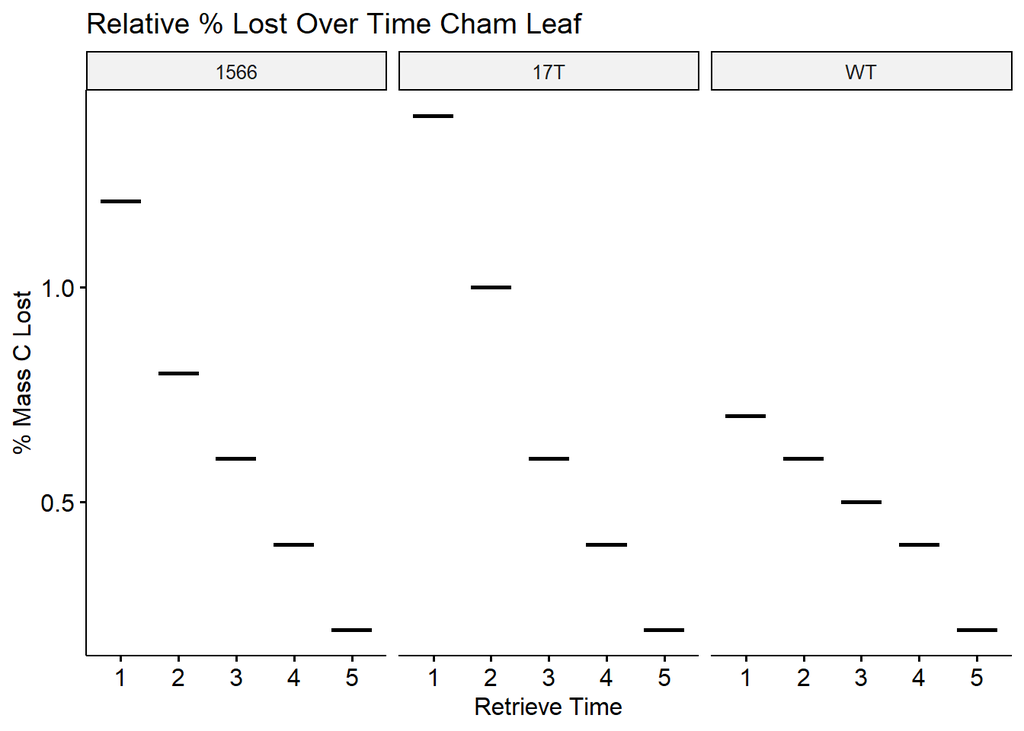

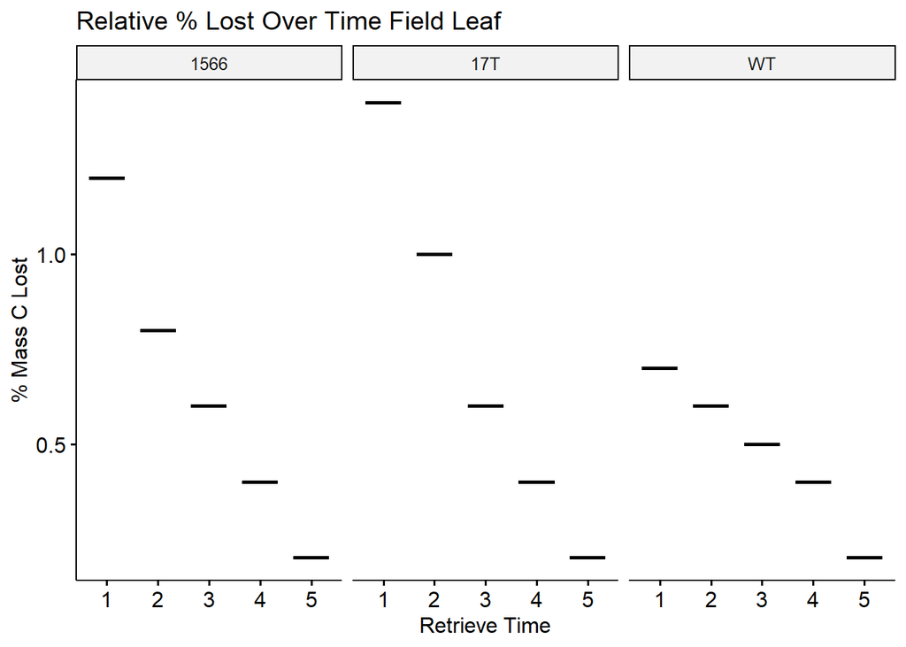

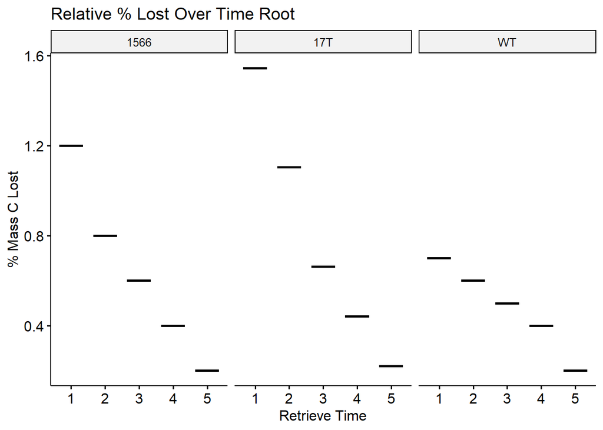

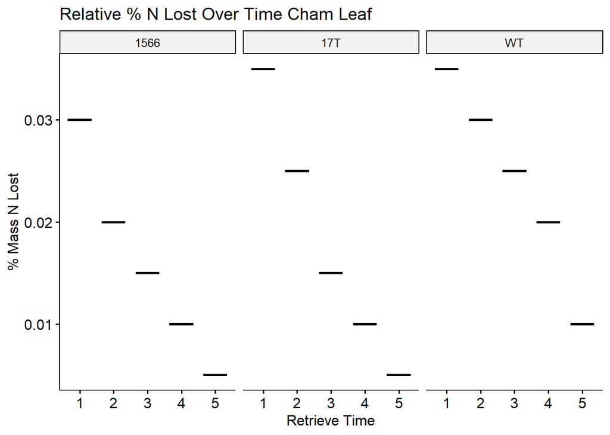

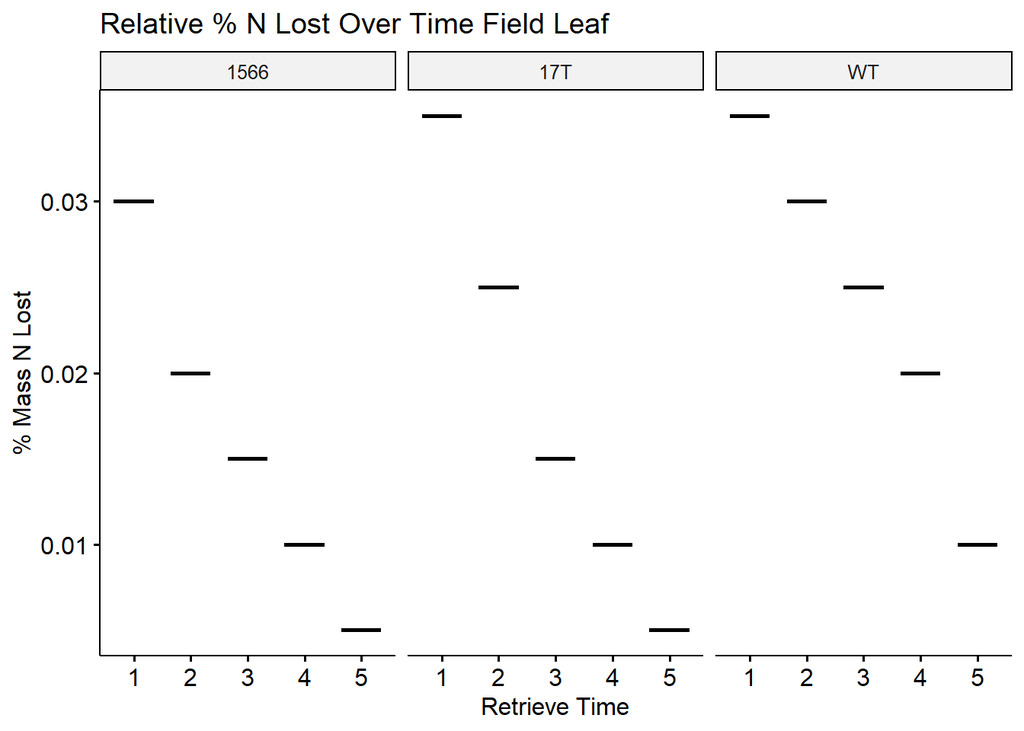

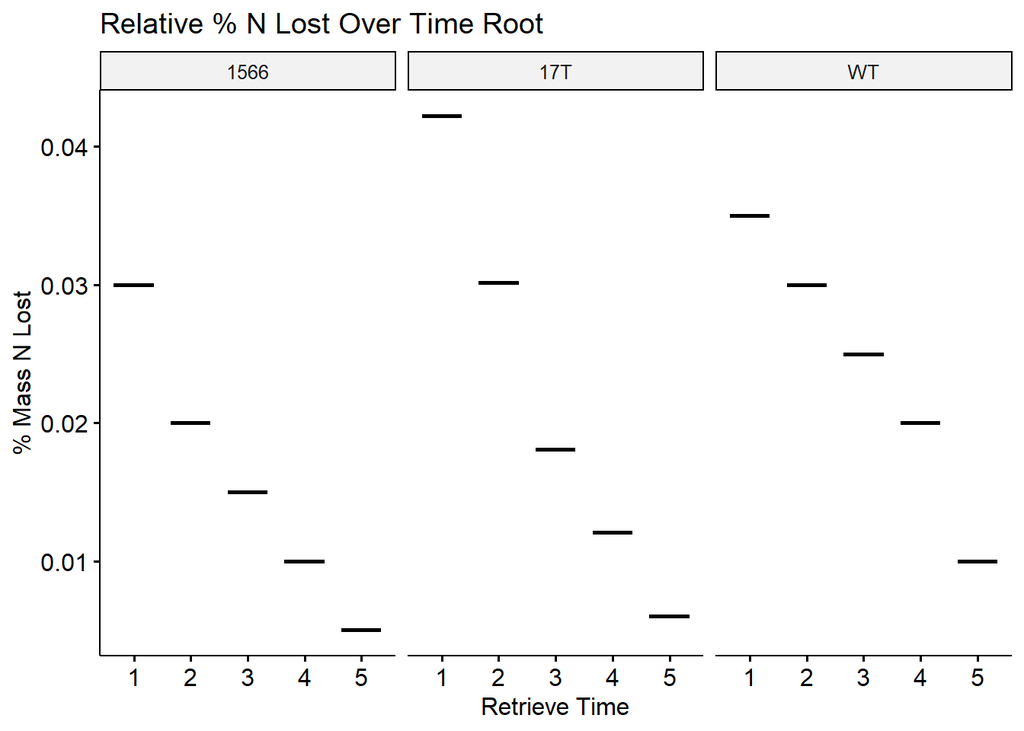

*Are there concerning outliers in the data?*

**There are no concerning outliers in the data.** The box plots results are lines rather than boxes because mock data percent mass lost is the same for each litter line and type combination at each retrieval time.

## Conclusions and Recomendations:

Results show that in leaves, wild type sugarcane litter decomposes more slowly than elevated-lipid litter. This was the opposite of the experiment’s hypothesis. In roots, wild type sugarcane litter decomposed more quickly than one of the elevated-lipid lines and more slowly than the other. If the lower quality lipid substrate is slowing down decomposition, other factors may be counteracting the effect as decomposition involves many interconnected steps.

The data showed no concerning outliers and produced the expected results, indicating that the script is performing the desired calculations.

### Supplemental Material

Calculations Flowchart

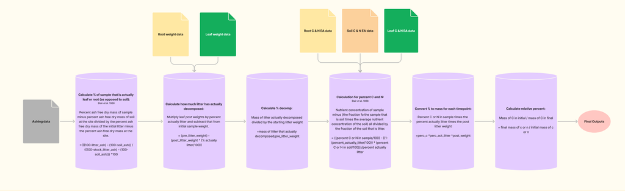